# Netlogo nldoc framework

## Introduction

This repository serves as an example showcase on how the nldoc framework (nldoc and nlrx) can be used for reproducible research with NetLogo and R. The main idea behind the framework ist to have everything related to the NetLogo model, model documentation and analysis in one place.

## Model Documentation

#### Documentation of code, gui, info tab and behavior space experiments:

Model documentation can be created with nldoc package.

```r
library(nldoc)
## Test nldoc creation:
modelfiles <- c("D:/owncloud/Rdev/nldoc_testpackage/Wolf Sheep Predation.nlogo",
                "D:/owncloud/Rdev/nldoc_testpackage/Wolf Sheep Predation Extra.nls")
nldoc(modelfiles = modelfiles,
      infotab=TRUE,
      gui=TRUE,
      bs=TRUE,
      outpath = "D:/owncloud/Rdev/nldoc_testpackage/nldoc_framework",
      output_format = "html",
      number_sections = TRUE,
      theme = "cosmo",
      date = date(),
      toc = TRUE)
```

[Open Model Documentation here](https://raw.githubusercontent.com/nldoc/nldoc_framework/master/nldoc.html)

#### Documentation of model procedure network

Nldoc also has a function to generate a procedure network plot:

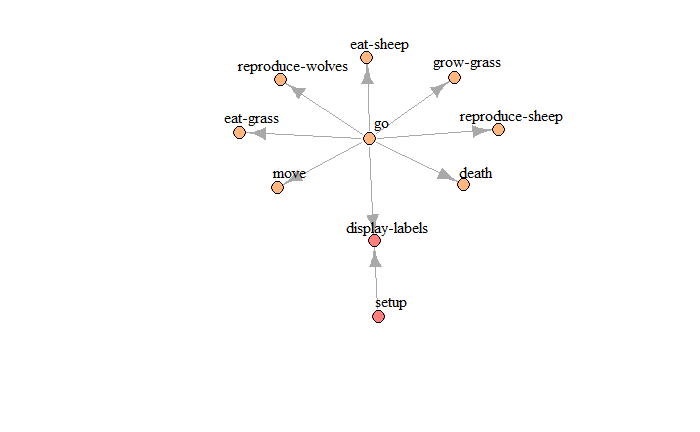

```r
# Read procedure network from modelfiles (nldoc)
nw <- procedure_nw(modelfiles)
library(igraph)
clp <- walktrap.community(nw)
V(nw)$community <- clp$membership
rain <- rainbow(14, alpha=.5)
V(nw)$color <- rain[V(nw)$community]
# Plot procedure graph:
plot(nw,
     edge.arrow.size=1,
     vertex.label.color="black",
     vertex.label.dist=2,
     vertex.size=10,
     edge.curved=0,
     vertex.label.cex=1,
     layout=layout_with_fr(nw, niter = 2000))
```

## Simulations

#### Experiment setup:

We use the nlrx package to run a simple model analysis. We want to know, how the grass regrowth time affects the number of sheep and wolves over time. To setup the simulations, we load the nlrx package. We then create a nl object and an experiment with parameter definitions. Finally, we attach a distinct simdesign.

```r
library(nlrx)
## Step1: Create a nl obejct:
nl <- nl(nlversion = "6.0.4",
         nlpath = "C:/Program Files/NetLogo 6.0.4",
         modelpath = modelfiles[1],
         jvmmem = 1024)
## Step2: Add Experiment
# Inspect the model available model parameters:
eval_variables_constants(nl)
```

```
All defined variables and constants are valid!
```

```r
nl@experiment <- experiment(expname = "eFast",
                            outpath = "C:/out",
                            repetition = 1,      # If repetitions is > 1, a different random seed will be set for each netlogo run
                            tickmetrics = "true",
                            idsetup = "setup",   # you can define multiple setup procedures with c()
                            idgo = "go",         # you can define multiple go procedures with c()
                            idfinal = NA_character_,  # you can define one or more final commands here
                            runtime = 100,
                            evalticks = seq(0,100),
                            metrics = c("count sheep", "count wolves"),
                            variables = list("grass-regrowth-time" = list(values=c(10, 20, 30, 40, 50, 60, 70, 80))
                            ),
                            constants = list("initial-number-sheep" = 100,
                                             "initial-number-wolves" = 50,
                                             "sheep-gain-from-food" = 4,
                                             "wolf-gain-from-food" = 20,
                                             "sheep-reproduce" = 4,
                                             "wolf-reproduce" = 5,
                                             "model-version" = "\"sheep-wolves-grass\"",
                                             "show-energy?" = "false")
)
nl@simdesign <- simdesign_distinct(nl=nl, nseeds=3)
```

```
Creating distinct simulation design
```

#### Postprocessing

We can now plot the results. Plot 1 shows the number of sheep in dependence of the grass-regrowth-time and 3 replications with different random-seeds.

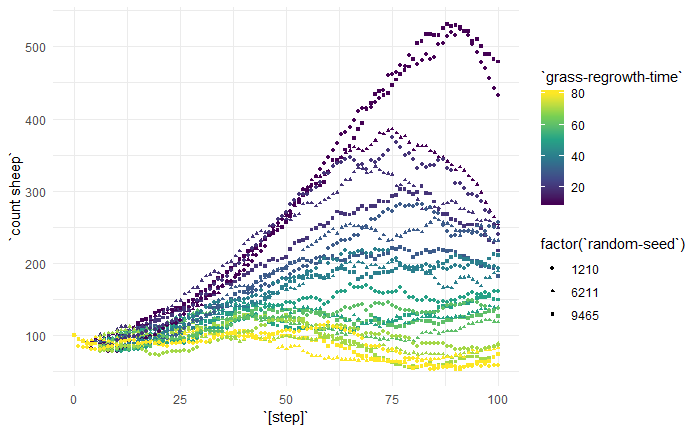

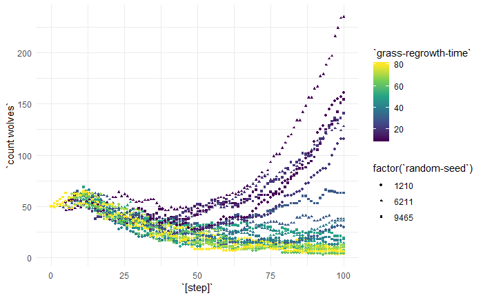